# Factors That Affect Insurance Charge to Patient

Sean Schilk

9/29/2025

# 1 Introduction

Two version of bootstrap procedures to generate bootstrap samples to estimate the confidence intervals of the coefficients of the regression model will be introduced in this project.

## 1.1 Data Set

I’m using a data set provided by Mosap Abdel-Ghany on Kaggle called “Medical Insurance Cost Dataset”. The data was collected from a collection of 1338 individuals from medical insurance records.

### 1.1.1 Data Description

The variables names in the data set and their variable type are the following:

- age (numeric)
- sex (character)
- BMI (numeric) - a measure of body fat based on height and weigh
- children (numeric) - Number of children covered by health insurance
- smoker (character) - Smoking status of the beneficiary
- region (character)- Residential region in the US
- charges (numeric) - Medical insurance cost billed to the beneficiary

## 1.2 Practical Question

The primary question is to identify the association between insurance charge and relevant predictor variables available in the data set.

# 2 Exploratory Data Analysis

We first explore the pairwise association between variables in the dataset. Since BMI and age are included, we begin by plotting these two variables to examine whether body mass index appears to vary systematically with age.

```r
library(readr)
insurance <- read_csv("https://raw.githubusercontent.com/sschilk/MySTA321/refs/heads/main/insurance.csv", show_col_types = FALSE)

# BMI and Age will be used to make a new variable in the upcoming analysis.

BMI <- insurance$bmi
age <- insurance$age

highRisk.group = (BMI > 38) & (age > 50)       # define the highRisk.group variable -- top right region = TRUE, other regions = FALSE

insurance$highRisk.group = as.character(highRisk.group)   # convert logical to character

# convert smoker variable ("yes"/"no") into numeric indicator (1 = yes, 0 = no)
insurance$smoker.ind = ifelse(insurance$smoker == "yes", 1, 0) # 1 for smoker


# keep only relevant variables for candidate models
final.data = insurance[, c("children", "smoker.ind", "charges", "highRisk.group")]

full.model = lm(charges ~ ., data = final.data)
## the final model

cmtrx <- summary(full.model)$coef

kable(cmtrx, caption = "Inferential Statistics of Final Model")
```

Inferential Statistics of Final Model

|  | Estimate | Std. Error | t value | Pr(>\|t\|) |
| --- | --- | --- | --- | --- |
| (Intercept) | 7417.0173 | 291.9098 | 25.408597 | 0.00e+00 |
| children | 659.0809 | 165.8539 | 3.973864 | 7.45e-05 |
| smoker.ind | 23667.5798 | 495.1060 | 47.803057 | 0.00e+00 |
| highRisk.groupTRUE | 7062.6952 | 1015.7184 | 6.953399 | 0.00e+00 |

The explicit expression of the final model is given by

$$full.model = 7417.0173 + 659.0809\times children + 23667.5798\times
smoker.ind + 7062.6952\times highRisk.groupTRUE$$
To interpret the regression coefficient, we choose the coefficient associated with **highRisk.group** In the output, you see the name of the dummy variable with the suffix TRUE, **highRisk.groupTRUE**. The suffix TRUE indicates that the dummy variable represents the category ‘TRUE’ of the category variable **highRisk.group**. The associated coefficient reflects the **mean** difference between the category TRUE and the baseline category FALSE. In R, the default baseline category is the lowest value of the categorical variable (in alphabetical order).

Let’s consider the set of all persons that are in the same conditions except the regions (region TRUE and region FALSE ) and the insurance charges.

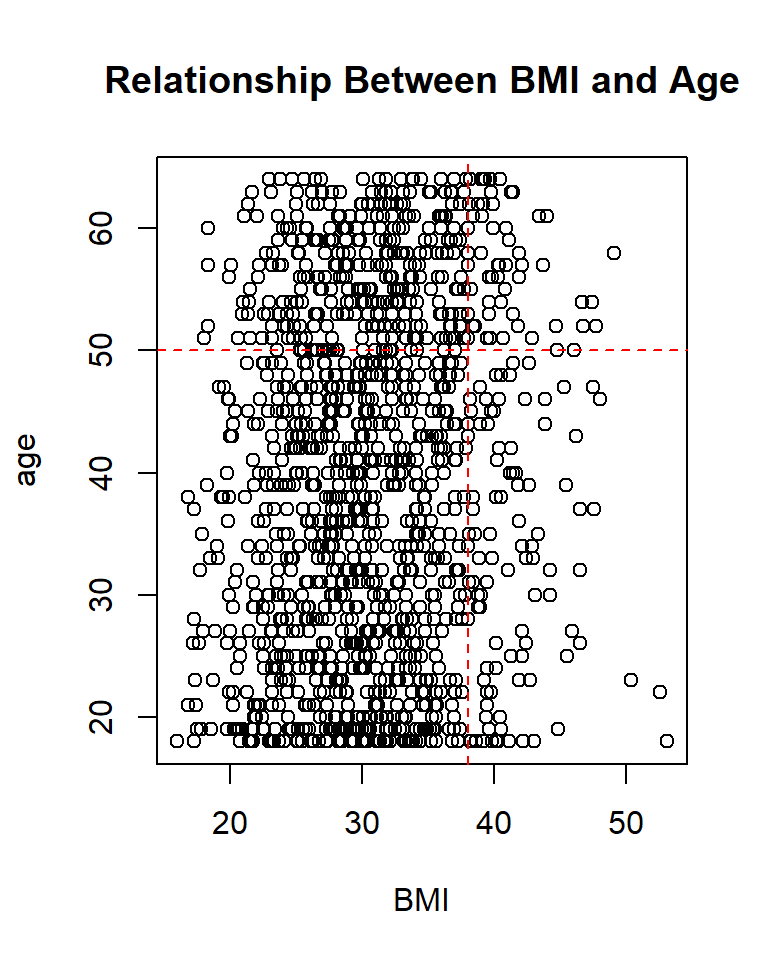

```r
plot(BMI, age, main = "Relationship Between BMI and Age")
abline(v=38, h=50, col="red", lty=2)
```

In the above graph, region **TRUE** would be the top right section, and all other regions would be **FALSE**.

# 3 Bootstrap CI for Regression Coefficients

In this section, we use bootstrapping cases to find the confidence intervals for the coefficients in the final regression model. The following code finds the confidence interval.

```r
##
B = 1000       # choose the number of bootstrap replicates.
num.p = dim(model.frame(full.model))[2]  # returns number of parameters in the model
smpl.n = dim(model.frame(full.model))[1] # sample size
## zero matrix to store bootstrap coefficients
coef.mtrx = matrix(rep(0, B*num.p), ncol = num.p)
for (i in 1:B){
  bootc.id = sample(1:smpl.n, smpl.n, replace = TRUE) # fit final model to the bootstrap sample
  full.model.btc = full.model = lm(charges ~ ., data  = final.data[bootc.id,])
  coef.mtrx[i,] = coef(full.model.btc)    # extract coefs from bootstrap regression model
}
```

The following code generates bootstrap confidence intervals of regression coefficients.

```r
boot.hist = function(cmtrx, bt.coef.mtrx, var.id, var.nm){
  ## bt.coef.mtrx = matrix for storing bootstrap estimates of coefficients
  ## var.id = variable ID (1, 2, ..., k+1)
  ## var.nm = variable name on the hist title, must be the string in the double quotes
  ## coefficient matrix of the final model
  ## Bootstrap sampling distribution of the estimated coefficients
  x1.1 <- seq(min(bt.coef.mtrx[,var.id]), max(bt.coef.mtrx[,var.id]), length=300 )
  y1.1 <- dnorm(x1.1, mean(bt.coef.mtrx[,var.id]), sd(bt.coef.mtrx[,var.id]))
  # height of the histogram - use it to make a nice-looking histogram.
  highestbar = max(hist(bt.coef.mtrx[,var.id], plot = FALSE)$density)
  ylimit <- max(c(y1.1,highestbar))
  hist(bt.coef.mtrx[,var.id], probability = TRUE, main = var.nm, xlab="",
       col = "azure1",ylim=c(0,ylimit), border="lightseagreen")
  lines(x = x1.1, y = y1.1, col = "red3")
  lines(density(bt.coef.mtrx[,var.id], adjust=2), col="blue")
  #legend("topright", c(""))
}
```

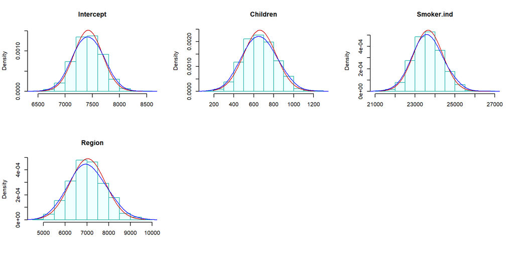

```r
par(mfrow=c(2,3))  # histograms of bootstrap coefs
boot.hist(bt.coef.mtrx=coef.mtrx, var.id=1, var.nm ="Intercept" )
boot.hist(bt.coef.mtrx=coef.mtrx, var.id=2, var.nm ="Children" )
boot.hist(bt.coef.mtrx=coef.mtrx, var.id=3, var.nm ="Smoker.ind" )
boot.hist(bt.coef.mtrx=coef.mtrx, var.id=4, var.nm ="Region" )
```

The red and blue curves are close to each other as we can see in the above histograms. so we would expect that significance test results and the corresponding bootstrap confidence intervals are consistent.

Next we want to find the 95% bootstrap confidence intervals of each regression coefficient, and combine them with the output of the final model:

```r
num.p = dim(coef.mtrx)[2]  # number of parameters
btc.ci = NULL
btc.wd = NULL
for (i in 1:num.p){
  lci.025 = round(quantile(coef.mtrx[, i], 0.025, type = 2),8)
  uci.975 = round(quantile(coef.mtrx[, i],0.975, type = 2 ),8)
  btc.wd[i] =  uci.975 - lci.025
  btc.ci[i] = paste("[", round(lci.025,4),", ", round(uci.975,4),"]")
 }
#as.data.frame(btc.ci)
kable(as.data.frame(cbind(formatC(cmtrx,4,format="f"), btc.ci.95=btc.ci)),
      caption = "Regression Coefficient Matrix")
```

Regression Coefficient Matrix

|  | Estimate | Std. Error | t value | Pr(>\|t\|) | btc.ci.95 |
| --- | --- | --- | --- | --- | --- |
| (Intercept) | 7417.0173 | 291.9098 | 25.4086 | 0.0000 | [ 6922.9361 , 7925.9681 ] |
| children | 659.0809 | 165.8539 | 3.9739 | 0.0001 | [ 365.3109 , 980.8184 ] |
| smoker.ind | 23667.5798 | 495.1060 | 47.8031 | 0.0000 | [ 22258.4893 , 25112.0265 ] |
| highRisk.groupTRUE | 7062.6952 | 1015.7184 | 6.9534 | 0.0000 | [ 5502.0686 , 8646.4511 ] |

We can see from the above table of summarized statistics, the significance tests of regression coefficients based on the p-values and the corresponding 95% confidence intervals are consistent.

# 4 Residual Bootstrap Regression

Here we use bootstrap residual methods to construct bootstrap confidence intervals.

The following code generates bootstrap confidence intervals of regression coefficients:

```r
## Final model
model.resid = full.model$residuals
B=1000
num.p = dim(model.matrix(full.model))[2]   # number of parameters
samp.n = dim(model.matrix(full.model))[1]  # sample size
btr.mtrx = matrix(rep(0,6*B), ncol=num.p) # zero matrix to store boot coefs
for (i in 1:B){
  ## Bootstrap response values
  bt.full.model = full.model$fitted.values +
        sample(full.model$residuals, samp.n, replace = TRUE)  # bootstrap residuals
  # replace charges with bootstrap full model
  final.data$bt.full.model =  bt.full.model   #  send the boot response to the data
 btr.model = lm(bt.full.model ~ children + smoker.ind + highRisk.group,
               data = final.data)
  # b
  btr.mtrx[i,]=btr.model$coefficients
}
```

Next, I make histograms of the residual bootstrap estimates of the regression coefficients.

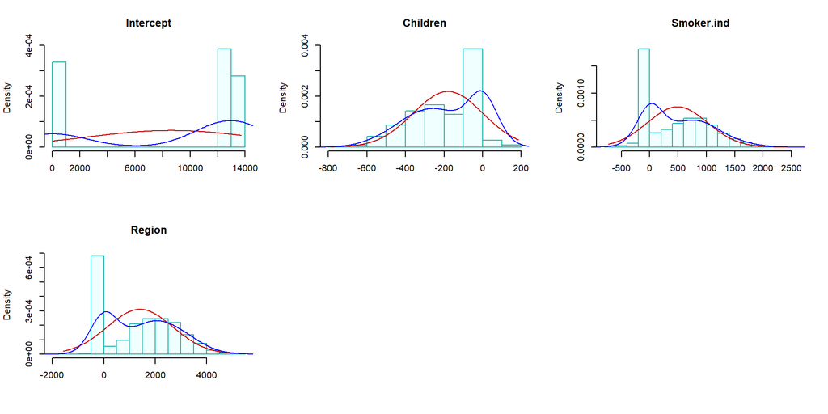

```r
boot.hist = function(bt.coef.mtrx, var.id, var.nm){
  ## bt.coef.mtrx = matrix for storing bootstrap estimates of coefficients
  ## var.id = variable ID (1, 2, ..., k+1)
  ## var.nm = variable name on the hist title, must be the string in the double quotes
  ## Bootstrap sampling distribution of the estimated coefficients
  x1.1 <- seq(min(bt.coef.mtrx[,var.id]), max(bt.coef.mtrx[,var.id]), length=300 )
  y1.1 <- dnorm(x1.1, mean(bt.coef.mtrx[,var.id]), sd(bt.coef.mtrx[,var.id]))
  # height of the histogram - use it to make a nice-looking histogram.
  highestbar = max(hist(bt.coef.mtrx[,var.id], plot = FALSE)$density)
  ylimit <- max(c(y1.1,highestbar))
  hist(bt.coef.mtrx[,var.id], probability = TRUE, main = var.nm, xlab="",
       col = "azure1",ylim=c(0,ylimit), border="lightseagreen")
  lines(x = x1.1, y = y1.1, col = "red3")       # normal density curve
  lines(density(bt.coef.mtrx[,var.id], adjust=2), col="blue")    # loess curve
}

par(mfrow=c(2,3))  # histograms of bootstrap coefs
boot.hist(bt.coef.mtrx=btr.mtrx, var.id=1, var.nm ="Intercept" )
boot.hist(bt.coef.mtrx=btr.mtrx, var.id=2, var.nm ="Children" )
boot.hist(bt.coef.mtrx=btr.mtrx, var.id=3, var.nm ="Smoker.ind" )
boot.hist(bt.coef.mtrx=btr.mtrx, var.id=4, var.nm ="Region" )
```

The residual bootstrap sampling distributions of each estimated regression coefficient show that the normal and LOESS curves are not close to each other. This indicates that inference about the significance of variables based on p-values may differ from the results obtained through residual bootstrap.

The 95% residual bootstrap confidence intervals are given in the following:

```r
num.p = dim(coef.mtrx)[2]  # number of parameters
btr.ci = NULL
btr.wd = NULL
for (i in 1:num.p){
  lci.025 = round(quantile(btr.mtrx[, i], 0.025, type = 2),8)
  uci.975 = round(quantile(btr.mtrx[, i],0.975, type = 2 ),8)
  btr.wd[i] = uci.975 - lci.025
  btr.ci[i] = paste("[", round(lci.025,4),", ", round(uci.975,4),"]")
}
#as.data.frame(btc.ci)
kable(as.data.frame(cbind(formatC(cmtrx,4,format="f"), btr.ci.95=btr.ci)),
      caption = "Regression Coefficient Matrix with 95% Residual Bootstrap CI")
```

Regression Coefficient Matrix with 95% Residual Bootstrap CI

|  | Estimate | Std. Error | t value | Pr(>\|t\|) | btr.ci.95 |
| --- | --- | --- | --- | --- | --- |
| (Intercept) | 7417.0173 | 291.9098 | 25.4086 | 0.0000 | [ 0 , 13417.4776 ] |
| children | 659.0809 | 165.8539 | 3.9739 | 0.0001 | [ -559.1214 , 34.7791 ] |
| smoker.ind | 23667.5798 | 495.1060 | 47.8031 | 0.0000 | [ -152.6719 , 1626.6476 ] |
| highRisk.groupTRUE | 7062.6952 | 1015.7184 | 6.9534 | 0.0000 | [ 0 , 3810.1168 ] |

# 5 Summary of Inferential Statistics

Finally, we put all inferential statistics in a single table so we can compare these results.

```r
kable(as.data.frame(cbind(formatC(cmtrx[,-3],4,format="f"), btc.ci.95=btc.ci,btr.ci.95=btr.ci)),
      caption="Final Combined Inferential Statistics: p-values and Bootstrap CIs")
```

Final Combined Inferential Statistics: p-values and Bootstrap CIs

|  | Estimate | Std. Error | Pr(>\|t\|) | btc.ci.95 | btr.ci.95 |
| --- | --- | --- | --- | --- | --- |
| (Intercept) | 7417.0173 | 291.9098 | 0.0000 | [ 6922.9361 , 7925.9681 ] | [ 0 , 13417.4776 ] |
| children | 659.0809 | 165.8539 | 0.0001 | [ 365.3109 , 980.8184 ] | [ -559.1214 , 34.7791 ] |
| smoker.ind | 23667.5798 | 495.1060 | 0.0000 | [ 22258.4893 , 25112.0265 ] | [ -152.6719 , 1626.6476 ] |
| highRisk.groupTRUE | 7062.6952 | 1015.7184 | 0.0000 | [ 5502.0686 , 8646.4511 ] | [ 0 , 3810.1168 ] |

## 5.1 Width of Bootstrap CIs

```r
kable(round(cbind(btc.wd, btr.wd),4), caption="width of the two bootstrap confidence intervals")
```

width of the two bootstrap confidence intervals

| btc.wd | btr.wd |
| --- | --- |
| 1003.0320 | 13417.4776 |
| 615.5076 | 593.9005 |
| 2853.5373 | 1779.3195 |
| 3144.3825 | 3810.1168 |

We see from the above table that the widths of residual-bootstrap and case-bootstrap confidence intervals are similar to each other for **children** and **highRisk.groupTRUE**. The Intercept and smoker.ind coefficients show noticeable differences in interval width between the residual-bootstrap (btr.wd) and case-bootstrap (btc.wd), which may reflect sensitivity to non normality and/or non constant variance.

# 6 Discussions

```r
kable(cmtrx, caption = "Inferential Statistics of Final Model")
```

Inferential Statistics of Final Model

|  | Estimate | Std. Error | t value | Pr(>\|t\|) |
| --- | --- | --- | --- | --- |
| (Intercept) | 7417.0173 | 291.9098 | 25.408597 | 0.00e+00 |
| children | 659.0809 | 165.8539 | 3.973864 | 7.45e-05 |
| smoker.ind | 23667.5798 | 495.1060 | 47.803057 | 0.00e+00 |
| highRisk.groupTRUE | 7062.6952 | 1015.7184 | 6.953399 | 0.00e+00 |

Regression coefficients explain the change in average charges associated with the corresponding explanatory variables, holding the other variables constant. As an example, consider the estimated regression coefficient of 7062.6952 for highRisk.groupTRUE. This means that, on average, patients in the highRisk.group = TRUE category are expected to have charges that are approximately $7,063 dollars higher than patients in the highRisk.group = FALSE category, assuming the number of children and smoking status remain the same.